# Báo cáo Kết quả Khảo sát Hài lòng (V2 - Scholarly)

Đổi mới chương trình tích hợp dựa trên năng lực khoa RHM

Tdy Pipeline

07/05/2026

# Bảng 1. Đặc điểm mẫu nghiên cứu (Table 1. Sample Demographics, N = 121)

**Bảng 1. Đặc điểm mẫu nghiên cứu (Table 1. Sample Demographics, N = 121)**

| **Characteristic** | **N = 121** |
| --- | --- |
| Giới tính (Gender), n (%) |  |
| Nam | 48 (39.7) |
| Nữ | 73 (60.3) |
| Thâm niên (Seniority - 4 groups), n (%) |  |
| Dưới 5 năm | 16 (13.2) |
| Từ 5 đến 10 năm | 30 (24.8) |
| Từ 10 đến 20 năm | 61 (50.4) |
| Trên 20 năm | 14 (11.6) |
| Thâm niên gộp (Seniority - collapsed), n (%) |  |
| <10 năm | 46 (38.0) |
| ≥10 năm | 75 (62.0) |

# Bảng 2. Trung vị và độ tin cậy các lĩnh vực hài lòng (Table 2. Median and Reliability)

Bảng 2. Trung vị và độ tin cậy các lĩnh vực hài lòng (Table 2. Median and Reliability)

| Lĩnh vực (Domain) | Số câu (Items) | Trung vị (Median) | IQR (Q1–Q3) | Min | Max | Cronbach’s α | p-value* |
| --- | --- | --- | --- | --- | --- | --- | --- |
| D1 – Khối lượng học tập | 6 | 4.00 | 4–4 | 1.00 | 5.00 | 0.96 | 0.000 |
| D2 – Cấu trúc & nội dung chương trình | 9 | 4.00 | 3.9–4 | 1.00 | 5.00 | 0.96 | 0.000 |
| D3 – Phương pháp giảng dạy & đánh giá | 9 | 4.00 | 4–4 | 3.00 | 5.00 | 0.89 | 0.000 |
| Overall satisfaction | 3 | 4.00 | 3.9–4 | 1.67 | 5.00 | 0.97 | 0.000 |

* Wilcoxon signed-rank test so với mốc trung tính = 3 (neutral).

*Ghi chú: p-value được tính từ kiểm định Wilcoxon signed-rank so với mốc trung tính = 3 (neutral).*

# Bảng 3A. So sánh mức độ hài lòng theo giới tính (Table 3A. Satisfaction by Gender)

**Bảng 3. So sánh mức độ hài lòng theo giới tính (Gender) (Table 3. Satisfaction comparison by giới tính (Gender))**

| **Lĩnh vực (Domain)** | **Nam** N = 48 | **Nữ** N = 73 | **p-value**<sup>1</sup> |
| --- | --- | --- | --- |
| D1 (Workload) |  |  | 0.77 |
| Median (Q1–Q3) | 4.0 (3.9–4.3) | 4.0 (4.0–4.0) |  |
| D2 (Content/Structure) |  |  | 0.19 |
| Median (Q1–Q3) | 4.0 (3.8–4.2) | 4.0 (4.0–4.0) |  |
| D3 (Teaching/Assessment) |  |  | 0.92 |
| Median (Q1–Q3) | 4.0 (3.9–4.1) | 4.0 (4.0–4.0) |  |
| Overall Satisfaction |  |  | 0.30 |
| Median (Q1–Q3) | 4.0 (3.9–4.1) | 4.0 (4.0–4.0) |  |

<sup>1</sup> Wilcoxon rank sum test

# Bảng 3B. So sánh mức độ hài lòng theo thâm niên giảng dạy (Table 3B. Satisfaction by Seniority)

**Bảng 3. So sánh mức độ hài lòng theo thâm niên giảng dạy (Seniority) (Table 3. Satisfaction comparison by thâm niên giảng dạy (Seniority))**

| **Lĩnh vực (Domain)** | **<10 năm** N = 46 | **≥10 năm** N = 75 | **p-value**<sup>1</sup> |
| --- | --- | --- | --- |
| D1 (Workload) |  |  | 0.93 |
| Median (Q1–Q3) | 4.0 (4.0–4.0) | 4.0 (4.0–4.0) |  |
| D2 (Content/Structure) |  |  | 0.75 |
| Median (Q1–Q3) | 4.0 (3.9–4.0) | 4.0 (4.0–4.0) |  |
| D3 (Teaching/Assessment) |  |  | 0.61 |
| Median (Q1–Q3) | 4.0 (3.9–4.0) | 4.0 (4.0–4.1) |  |
| Overall Satisfaction |  |  | 0.48 |
| Median (Q1–Q3) | 4.0 (3.9–4.0) | 4.0 (4.0–4.1) |  |

<sup>1</sup> Wilcoxon rank sum test

# Bảng 4. Các câu hỏi có điểm hài lòng thấp nhất (Table 4. Pain points)

Bảng 4. Các câu hỏi có điểm hài lòng thấp nhất (Table 4. Pain points)

| Câu hỏi (Item) | Trung vị (Median) | IQR | % Đồng ý (Agree) | % Không đồng ý (Disagree) |
| --- | --- | --- | --- | --- |
| D1_2: Số tiết lý thuyết và thực hành được phân bố hợp lý | 4 | 4–4 | 86.8 | 6.6 |
| D1_1: Phù hợp với khả năng tiếp thu của người học | 4 | 4–4 | 91.7 | 5.0 |
| D1_5: Khối lượng học tập cho phép người học có thời gian tự học và nghiên cứu | 4 | 4–4 | 88.4 | 5.0 |
| D1_6: Đánh giá của cá nhân về khối lượng học tập của sinh viên | 4 | 4–4 | 86.8 | 5.0 |
| D1_3: Giúp người học phát triển kỹ năng cần thiết cho nghề nghiệp tương lai | 4 | 4–4 | 91.7 | 3.3 |

# Biểu đồ 1. Mức độ đồng thuận các khía cạnh cốt lõi (Figure 1. Likert Agreement)

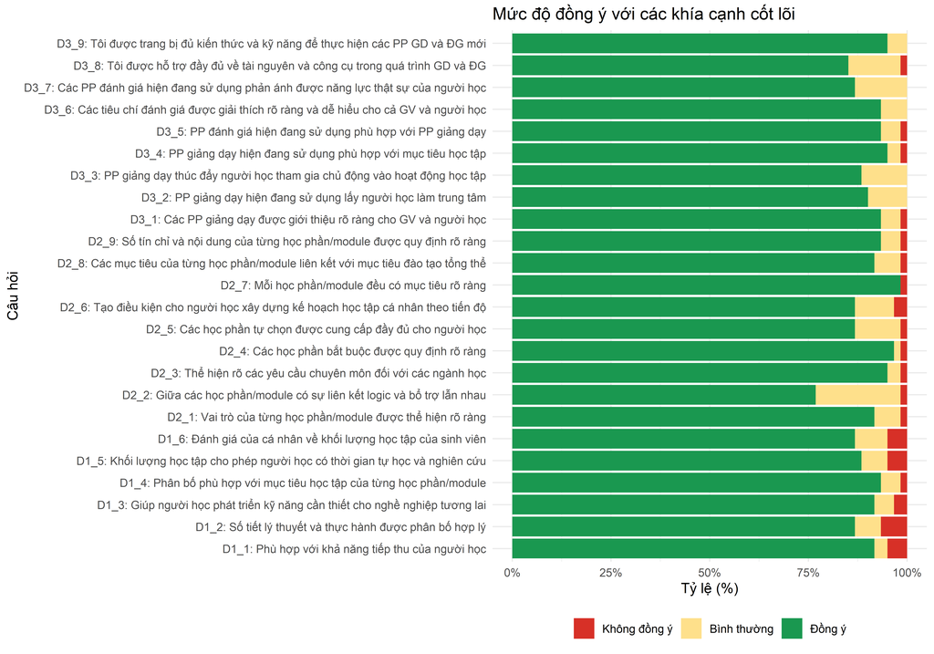

# Biểu đồ 2. So sánh điểm theo thâm niên (Figure 2. Satisfaction by Seniority)

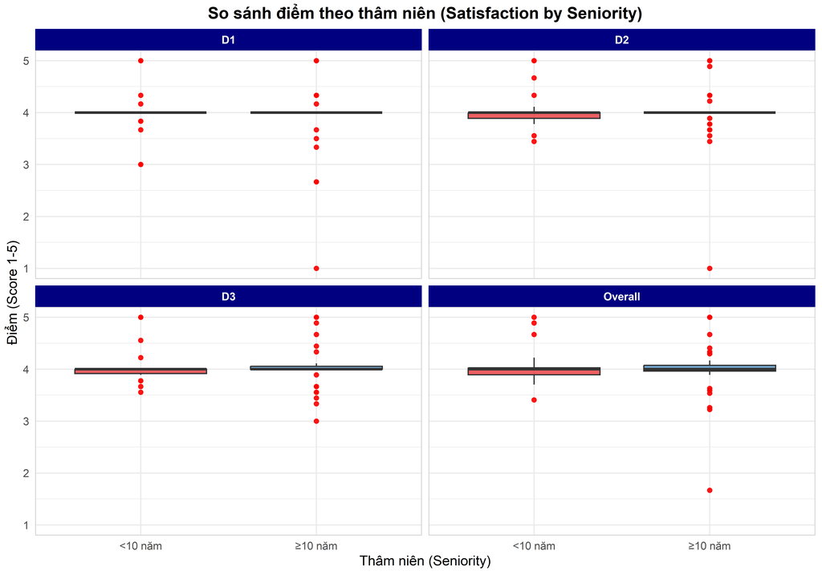

# Biểu đồ 3. Heatmap tương quan Spearman (Figure 3. Spearman Heatmap)

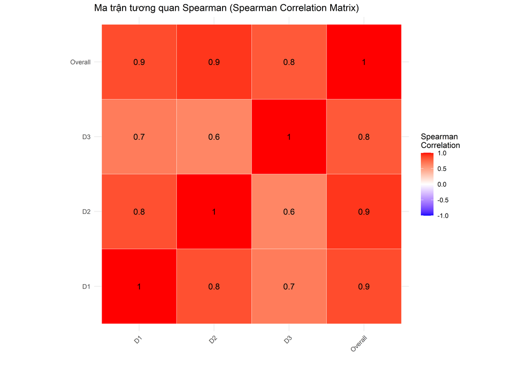

### Nhận xét (Comments)

- Các lĩnh vực liên hệ thuận mức trung bình–mạnh (Positive correlation).
- D2 (Nội dung) có tương quan mạnh nhất với hài lòng chung (Strongest link to Overall Satisfaction).